# Project 2: Exploring Temperature and Rainfall in Australia

Yunyi Ru

2024-10-02

# Note

*Apologize for my late submission*. *The [underground fire in downtown Baltimore caused Internet outage](https://www.reddit.com/r/baltimore/comments/1fstzm3/how_far_does_the_wifi_outage_spread/) in my apartment over the weekend*.

# Set Up

```r
library("here")
library("tidyverse")
```

```r
library('tidytuesdayR')
library('ggplot2')
theme_set(theme_bw())
library('knitr')
library('tidyr')
library('dplyr')
library('stringr')
library('lubridate')

# set seed for randomly generated tests
set.seed(1)

# set theme for graphics
source(here('labtheme.R'))
lab_theme <- lab_theme +
  theme(
    plot.subtitle = element_text(size = 8),
    plot.caption = element_text(size = 8),
    plot.title = element_text(hjust = 0)
  )
theme_set(lab_theme)
```

# Part 1: Fun with Functions

## Part 1A: Exponential Transformation

Q: The exponential of a number can be written as an infinite series expansion of the form
$$\exp(x) = 1 + x + \frac{x^2}{2!} + \frac{x^3}{3!} + \cdots$$
Of course, we cannot compute an infinite series by the end of this term and so we must truncate it at a certain point in the series. The truncated sum of terms represents an approximation to the true exponential, but the approximation may be usable.

Write a function that computes the exponential of a number using the truncated series expansion. The function should take two arguments:

- `x`: the number to be exponentiated
- `k`: the number of terms to be used in the series expansion beyond the constant 1. The value of `k` is always $\geq 1$.

For example, if $k = 1$, then the `Exp` function should return the number $1 + x$. If $k = 2$, then you should return the number $1 + x + x^2/2!$.

Include at least one example of output using your function.

```r
# exponential function (x is a single number, k >= 1)
Exp <- function(x, k) {
  value <- 0 # set initial value
  for (i in 0:k) {
    term <- x ^ i / factorial(i)
    value <- value + term # for each i, calculate its respective term value, add to the initial value
  }
  return(value) # return the result
}
```

### Test

```r
# test: x = 0, k = 1
Exp(0, 1)
```

```
## [1] 1
```

```r
# test: random
Exp(7, 100)
```

```
## [1] 1096.633
```

## Part 1B: Sample Mean and Sample Standard Deviation

Next, write two functions called `sample_mean()` and `sample_sd()` that takes as input a vector of data of length $N$ and calculates the sample average and sample standard deviation for the set of $N$ observations.

$$\bar{x} = \frac{1}{N} \sum_{i=1}^n x_i$$
$$s = \sqrt{\frac{1}{N-1} \sum_{i=1}^N (x_i - \overline{x})^2}$$
As a primer, the $\sum_{i = 1}^3 x_i$ is equivalent to doing the sum of $x_i$ starting from $i = 1$, increasing $i$ by 1 each then, up to when $i = 3$. That is, $x_1 + x_2 + x_3$.

Include at least one example of output using your functions.

```r
# function: mean
sample_mean <- function(x) {
  result <- 0 # set initial value
  sum <- 0
  N <- length(x)

  for (i in x) {
    # loop over the vector sequence
    sum <- sum + i
  }

  result <- sum / N # calculate the result
  return(result)
}

# function: sd
sample_sd <- function(x) {
  if (length(x) > 1) {
    result <- 0 # set initial value
    var <- 0
    N <- length(x)

    for (i in x) {
      # loop over the vector sequence
      var <- var + (sample_mean(x) - i) ^ 2 # calculate variance
    }

    result <- sqrt(var / (N - 1)) # calculate sd
    return(result)

  } else {
    # in case the input has a length of 0 or 1
    return(NA)
  }
}
```

### Test

```r
# test: single number
i <- 22
sample_mean(i)
```

```
## [1] 22
```

```r
sample_sd(i)
```

```
## [1] NA
```

```r
# test: random
x <- sample(5:90, 80, replace = TRUE)
sample_mean(x)
```

```
## [1] 48.1625
```

```r
sample_sd(x)
```

```
## [1] 23.96064
```

## Part 1C: Confidence Intervals

Next, write a function called `calculate_CI()` that:

1. There should be two inputs to the `calculate_CI()`. First, it should take as input a vector of data of length $N$. Second, the function should also have a `conf` ($=1-\alpha$) argument that allows the confidence interval to be adapted for different $\alpha$.
2. Calculates a confidence interval (CI) (e.g. a 95% CI) for the estimate of the mean in the population. If you are not familiar with confidence intervals, it is an interval that contains the population parameter with probability $1-\alpha$ taking on this form

$$\bar{x} \pm t_{\alpha/2, N-1} s_{\bar{x}}
= ( \bar{x} - t_{\alpha/2, N-1} s_{\bar{x}}, \bar{x} + t_{\alpha/2, N-1}
s_{\bar{x}} )$$

where $t_{\alpha/2, N-1}$ is the value needed to generate an area of $\alpha / 2$ in each tail of the $t$-distribution with $N-1$ degrees of freedom and $s_{\bar{x}} = \frac{s}{\sqrt{N}}$ is the standard error of the mean.

3. Returns a named vector of length 2, where the first value is the `lower_bound`, the second value is the `upper_bound`.

```r
# function: CI
calculate_CI <- function(x, conf = 0.95) { # default conf set to 0.95
  # set initial values
  N = length(x) # sample size
  x.bar = mean(x) # mean
  sd = sd(x) # standard deviation

  # critical value
  z = qt(p = (1-conf)/2, df = N-1, lower.tail = FALSE)

  # CI
  lower_bound = x.bar - z*sd/sqrt(N)
  upper_bound = x.bar + z*sd/sqrt(N)

  # return result
  results <- c(lower_bound, upper_bound) # save as vector
  return(results)
}
```

Include example of output from your function showing the output when using two different levels of `conf`.

### Test

```r
# Test 1: conf = 0.95
x <- sample(1:10, 80, replace = TRUE)
calculate_CI(x, conf = 0.95)
```

```
## [1] 4.582448 5.892552
```

```r
dat <- data.frame(x = x)
fit <- lm(x ~ 1, dat)

# Calculate a 95% confidence interval
confint(fit, level = 0.95)
```

```
##                2.5 %   97.5 %
## (Intercept) 4.582448 5.892552
```

```r
# Test 2: conf = 0.99
x <- sample(1:10, 80, replace = TRUE)
calculate_CI(x, conf = 0.99)
```

```
## [1] 5.003382 6.696618
```

```r
dat <- data.frame(x = x)
fit <- lm(x ~ 1, dat)

# Calculate a 95% confidence interval
confint(fit, level = 0.99)
```

```
##                0.5 %   99.5 %
## (Intercept) 5.003382 6.696618
```

# Part 2: Wrangling Data

```r
# download data
if (!file.exists(here("data", "tuesdata_rainfall.RDS"))) {
  tuesdata <- tidytuesdayR::tt_load("2020-01-07")
  rainfall <- tuesdata$rainfall
  temperature <- tuesdata$temperature

# save the files to RDS objects
saveRDS(tuesdata$rainfall, file = here("data", "tuesdata_rainfall.RDS"))
saveRDS(tuesdata$temperature, file = here("data", "tuesdata_temperature.RDS"))}

# load data
rainfall <- readRDS(here("data", "tuesdata_rainfall.RDS"))
temperature <- readRDS(here("data", "tuesdata_temperature.RDS"))

# have a look at the data
glimpse(rainfall)
```

```
## Rows: 179,273
## Columns: 11
## $ station_code <chr> "009151", "009151", "009151", "009151", "009151", "009151…
## $ city_name    <chr> "Perth", "Perth", "Perth", "Perth", "Perth", "Perth", "Pe…
## $ year         <dbl> 1967, 1967, 1967, 1967, 1967, 1967, 1967, 1967, 1967, 196…
## $ month        <chr> "01", "01", "01", "01", "01", "01", "01", "01", "01", "01…
## $ day          <chr> "01", "02", "03", "04", "05", "06", "07", "08", "09", "10…
## $ rainfall     <dbl> NA, NA, NA, NA, NA, NA, NA, NA, NA, NA, NA, NA, NA, NA, N…
## $ period       <dbl> NA, NA, NA, NA, NA, NA, NA, NA, NA, NA, NA, NA, NA, NA, N…
## $ quality      <chr> NA, NA, NA, NA, NA, NA, NA, NA, NA, NA, NA, NA, NA, NA, N…
## $ lat          <dbl> -31.96, -31.96, -31.96, -31.96, -31.96, -31.96, -31.96, -…
## $ long         <dbl> 115.79, 115.79, 115.79, 115.79, 115.79, 115.79, 115.79, 1…
## $ station_name <chr> "Subiaco Wastewater Treatment Plant", "Subiaco Wastewater…
```

```r
glimpse(temperature)
```

```
## Rows: 528,278
## Columns: 5
## $ city_name   <chr> "PERTH", "PERTH", "PERTH", "PERTH", "PERTH", "PERTH", "PER…
## $ date        <date> 1910-01-01, 1910-01-02, 1910-01-03, 1910-01-04, 1910-01-0…
## $ temperature <dbl> 26.7, 27.0, 27.5, 24.0, 24.8, 24.4, 25.3, 28.0, 32.6, 35.9…
## $ temp_type   <chr> "max", "max", "max", "max", "max", "max", "max", "max", "m…
## $ site_name   <chr> "PERTH AIRPORT", "PERTH AIRPORT", "PERTH AIRPORT", "PERTH …
```

Using the `rainfall` and `temperature` data, perform the following steps and create a new data frame called `df`:

1. Start with `rainfall` dataset and drop any rows with NAs.
2. Create a new column titled `date` that combines the columns `year`, `month`, `day` into one column separated by “-”. (e.g. “2020-01-01”). This column should not be a character, but should be recognized as a date. (**Hint**: check out the `ymd()` function in `lubridate` R package). You will also want to add a column that just keeps the `year`.
3. Using the `city_name` column, convert the city names (character strings) to all upper case.
4. Join this wrangled rainfall dataset with the `temperature` dataset such that it includes only observations that are in both data frames. (**Hint**: there are two keys that you will need to join the two datasets together). (**Hint**: If all has gone well thus far, you should have a dataset with 83,964 rows and 13 columns).

```r
# Step 1: drop NA
df <- rainfall %>%
  drop_na()

# Step 2: Set up 'date'
df <- df %>%
  mutate(date = ymd(paste(year, month, day, sep = '-'))) %>%
  select(-month, -day) # drop unused columns

# Step 3: Convert 'city_name' to all uppercase
df <- df %>%
  mutate(city_name = str_to_upper(city_name))

# Step 4: Join the dataset with 'temperature'
df <- inner_join(df, temperature, by = c('city_name', 'date'))
```

# Part 3: Data Visualization

In this part, we will practice our `ggplot2` plotting skills within the tidyverse starting with our wrangled `df` data from Part 2. For full credit in this part (and for all plots that you make), your plots should include:

1. An overall title for the plot and a subtitle summarizing key trends that you found. Also include a caption in the figure.
2. There should be an informative x-axis and y-axis label.

Consider playing around with the `theme()` function to make the figure shine, including playing with background colors, font, etc.

## Part 3A: Plotting temperature data over time

Use the functions in `ggplot2` package to make a line plot of the max and min temperature (y-axis) over time (x-axis) for each city in our wrangled data from Part 2. You should only consider years 2014 and onwards. For full credit, your plot should include:

1. For a given city, the min and max temperature should both appear on the plot, but they should be two different colors.
2. Use a facet function to facet by `city_name` to show all cities in one figure.

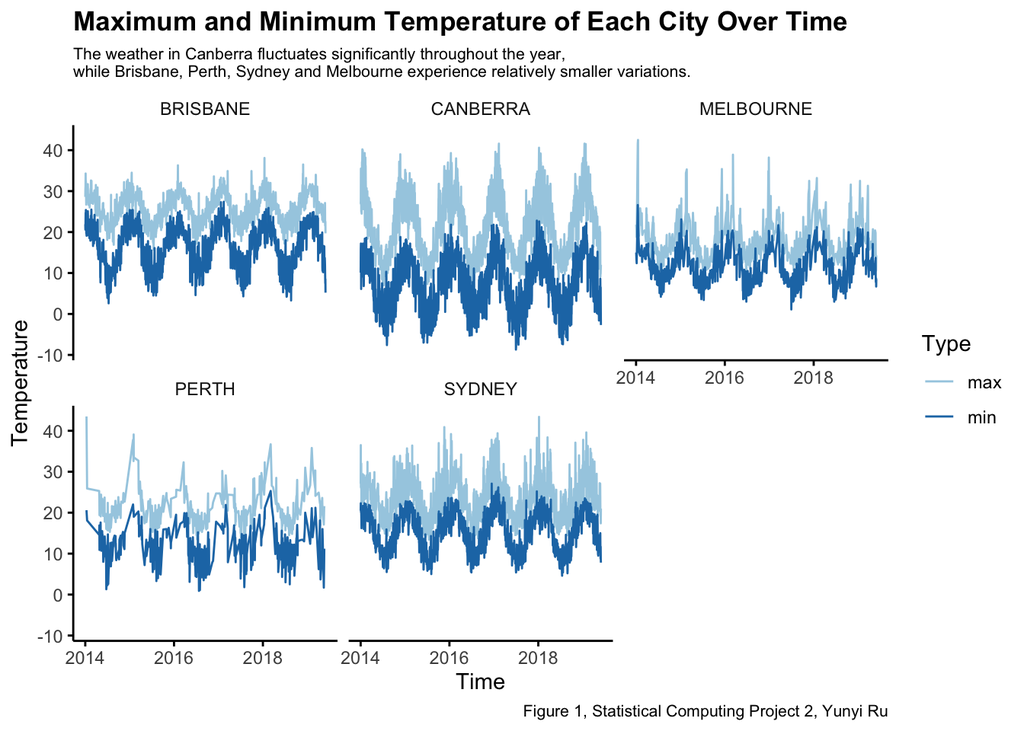

```r
# Add your solution here
df_3A <- df %>%
  filter(year >= 2014)

ggplot(data = df_3A, aes(x = date, y = temperature, color = temp_type)) +
  geom_line() +
  facet_wrap( ~ city_name) + # facet by city name
  labs(title = 'Maximum and Minimum Temperature of Each City Over Time',
       subtitle = 'The weather in Canberra fluctuates significantly throughout the year, \nwhile Brisbane, Perth, Sydney and Melbourne experience relatively smaller variations.',
       caption = 'Figure 1, Statistical Computing Project 2, Yunyi Ru',
       color = 'Type',
       x = 'Time',
       y = 'Temperature') +
  scale_color_brewer(palette = 'Paired')
```

## Part 3B: Plotting rainfall over time

Here we want to explore the distribution of rainfall (log scale) with histograms for a given city (indicated by the `city_name` column) for a given year (indicated by the `year` column) so we can make some exploratory plots of the data.

The following code plots the data from one city (`city_name == "PERTH"`) in a given year (`year == 2000`).

```r
df %>%
    filter(city_name == "PERTH", year == 2000) %>%
    ggplot(aes(log(rainfall))) +
    geom_histogram()
```

While this code is useful, it only provides us information on one city in one year. We could cut and paste this code to look at other cities/years, but that can be error prone and just plain messy.

The aim here is to **design** and **implement** a function that can be re-used to visualize all of the data in this dataset.

1. There are 2 aspects that may vary in the dataset: The **city_name** and the **year**. Note that not all combinations of `city_name` and `year` have measurements.
2. Your function should take as input two arguments **city_name** and **year**.
3. Given the input from the user, your function should return a **single** histogram for that input. Furthermore, the data should be **readable** on that plot so that it is in fact useful. It should be possible visualize the entire dataset with your function (through repeated calls to your function).
4. If the user enters an input that does not exist in the dataset, your function should catch that and report an error (via the `stop()` function).

For this section,

1. Write a short description of how you chose to design your function and why.
2. Present the code for your function in the R markdown document.
3. Include at least one example of output from your function.

```r
rainfall_city_over_time <- function(c, y) {
  if (c %in% df$city_name) {
    if (y %in% df$year[df$city_name == c]) {
      df %>%
        filter(city_name == c, year == y) %>%
        ggplot(aes(log(rainfall))) +
        geom_histogram(fill = '#4A90E2') +
        labs(
          title = paste('Rainfall over time,', c, y),
          subtitle = paste('This plot shows the rainfall over time of the city', c, 'in year', y, '.'),
          caption = 'Figure 2, Statistical Computing Project 2, Yunyi Ru',
          y = 'Count',
          x = 'Rainfall (Log10mm)'
        )
    } else {
      stop('Input year not valid. Check Again.')
    }
  } else {
    stop('Input city not valid. Check Again.')
  }
}
```

### Test

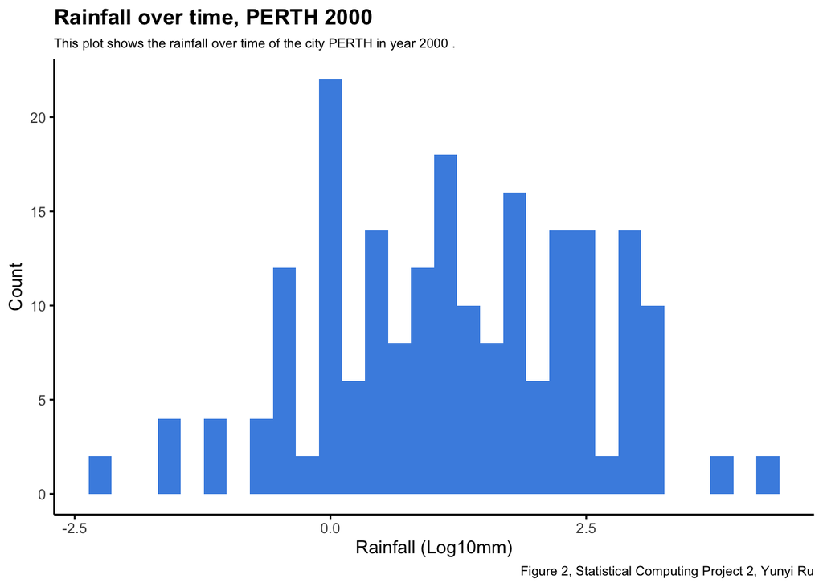

```r
# Valid Test 1
rainfall_city_over_time('PERTH', 2000)
```

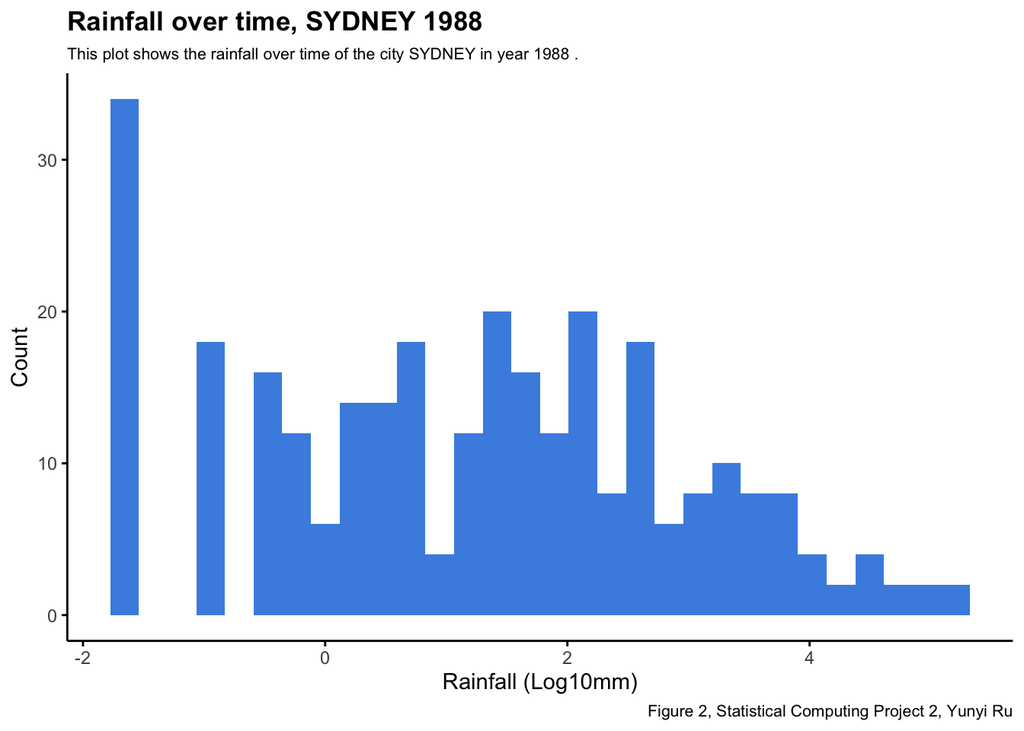

```r
# Valid Test 2
rainfall_city_over_time('SYDNEY', 1988)
```

```r
# Invalid City Name
rainfall_city_over_time('BEIJING', 2000)
```

```
## Error in rainfall_city_over_time("BEIJING", 2000): Input city not valid. Check Again.
```

```r
# Valid City Name, Invalid Year
rainfall_city_over_time('PERTH', 42)
```

```
## Error in rainfall_city_over_time("PERTH", 42): Input year not valid. Check Again.
```

## Description

This function mainly uses 2 if-else structures. First if-else structure makes sure that the input city is valid, and the second if-else structure makes sure that the input year is valid within the input city. If all inputs are valid, it just generates a histogram (title customized using the `paste()` function). If not, it will returns an error message.

# Part 4: Apply Functions and Plot

## Part 4A: Tasks

In this part, we will apply the functions we wrote in Part 1 to our rainfall data starting with our wrangled `df` data from Part 2.

1. First, filter for only years including 2014 and onwards.
2. For a given city and for a given year, calculate the sample mean (using your function `sample_mean()`), the sample standard deviation (using your function `sample_sd()`), and a 95% confidence interval for the average rainfall (using your function `calculate_CI()`). Specifically, you should add two columns in this summarized dataset: a column titled `lower_bound` and a column titled `upper_bound` containing the lower and upper bounds for you CI that you calculated (using your function `calculate_CI()`).
3. Call this summarized dataset `rain_df`.

```r
# Step 1: filter data
df_4A <- df %>%
  filter(year >= 2014)

# Step 2/3: summary
rain_df <- df_4A %>%
  group_by(city_name, year) %>%
  summarise(mean = sample_mean(rainfall),
            sd = sample_sd(rainfall),
            CI_lower = calculate_CI(rainfall)[1],
            CI_upper = calculate_CI(rainfall)[2])
# check
print(rain_df)
```

```
## # A tibble: 30 × 6
## # Groups:   city_name [5]
##    city_name  year  mean    sd CI_lower CI_upper
##    <chr>     <dbl> <dbl> <dbl>    <dbl>    <dbl>
##  1 BRISBANE   2014  3.84 12.3      2.99     4.69
##  2 BRISBANE   2015  6.17 22.7      4.53     7.82
##  3 BRISBANE   2016  2.09  8.61     1.47     2.72
##  4 BRISBANE   2017  2.72 10.2      1.97     3.47
##  5 BRISBANE   2018  2.47  9.63     1.75     3.19
##  6 BRISBANE   2019  2.10  6.35     1.38     2.82
##  7 CANBERRA   2014  1.57  4.84     1.22     1.92
##  8 CANBERRA   2015  1.51  5.16     1.13     1.89
##  9 CANBERRA   2016  2.15  6.28     1.70     2.61
## 10 CANBERRA   2017  1.34  4.12     1.04     1.64
## # ℹ 20 more rows
```

## Part 4B: Tasks

Using the `rain_df`, plots the estimates of *mean rainfall* and *the 95% confidence intervals* on the same plot. There should be a separate faceted plot for each city.

Think about using `ggplot()` with both `geom_point()` (and `geom_line()` to connect the points) for the means and `geom_errorbar()` for the lower and upper bounds of the confidence interval. Check https://r-graphics.org/recipe-annotate-error-bar and or the official documentation https://ggplot2.tidyverse.org/reference/geom_linerange.html for examples of how to use `geom_errorbar()`.

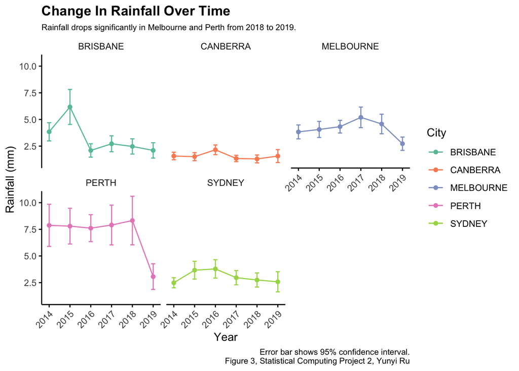

```r
ggplot(data = rain_df, aes(x = year, y = mean, color = city_name)) +
  geom_point() +
  geom_line() +
  geom_errorbar(aes(ymin = CI_lower, ymax = CI_upper), width = 0.2) +
  facet_wrap( ~ city_name) +
  scale_color_brewer(palette = 'Set2') +
  labs(
    title = 'Change In Rainfall Over Time',
    subtitle = 'Rainfall drops significantly in Melbourne and Perth from 2018 to 2019.',
    caption = 'Error bar shows 95% confidence interval.\nFigure 3, Statistical Computing Project 2, Yunyi Ru',
    y = 'Rainfall (mm)',
    x = 'Year',
    color = 'City'
  ) +
  theme(axis.text.x = element_text(angle = 45, hjust = 1))
```